# 计量经济学实验报告写作要求

Li Zongzhang

2022-12-21

**封面**

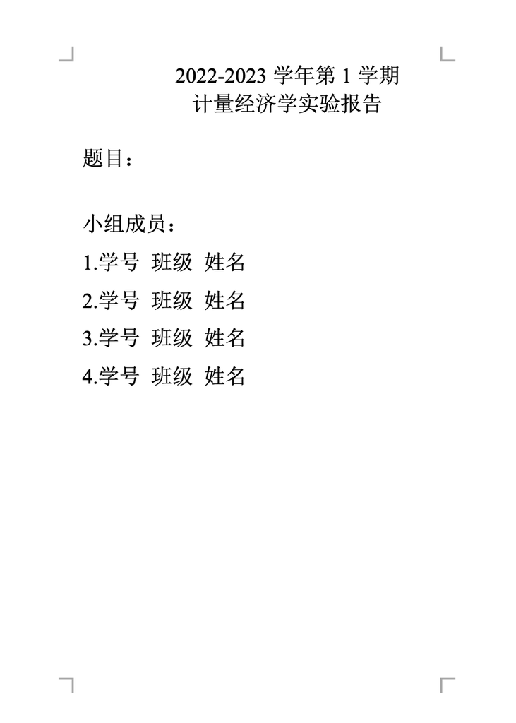

# 1 **引言**

- 介绍选题动机、研究目标、研究意义

# 2 **理论假说**

- 提出期望证明的理论假说(观点)
- 对理论假说进行简要的解释“为什么对变量之间的关系有这样的预期”

# 3 **数据概况**

- 样本是如何选取的？简要描述数据收集过程
- 样本容量
- 变量的含义
- 变量的描述性统计分析（报告模型中所有变量的均值、中位数、最小值、最大值、标准差）

# 4 **实证分析**

## 4.1 **模型设定**

- 设定经济计量模型的表达式
- 解释为什么将经济计量模型设定为该形式
- 选用在前期小组作业中你认为**最合适**的一个或几个模型
- 不要写模型的尝试的过程

## 4.2 **参数估计结果**

- 报告**最合适**的模型的估计结果
  - 以如下表格形式报告模型估计结果
  - 简要解释为什么选择上述模型，该模型为什么是一个“好的”模型

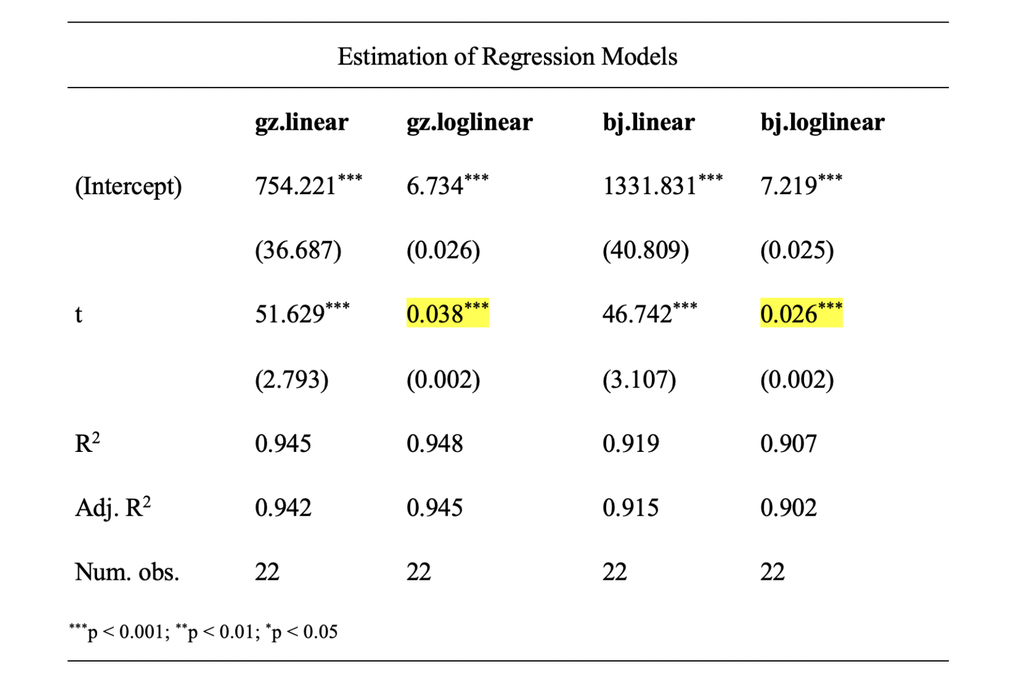

## 4.3 **模型诊断**

- 将下述检验的R的输出结果截图，并进行简要解释
  - 残差的图形诊断
  - 多余或遗漏变量的检验
  - 多重共线性诊断
  - 异方差检验

## 4.4 **估计结果解释**

- 对模型的估计结果进行解释
  - 对于显著的系数，解释其含义，讨论与现实是否一致，估计结果的合理性。
  - 对于不显著的系数，结合现实，解释其为什么不显著，可能的原因是什么。
  - 评估模型的合理性

# 5 **结论和启示**

## 5.1 **研究结论**

- 概括实证研究的主要结论

## 5.2 **启示**

- 从实证研究的结论中得到的启示
- 本研究的现实意义

# 6 **R代码**

- R代码截图

# 7 **心得体会**

- 小组成员1学号 姓名 班级 个人心得体会
  - 本人在小组案例作业和实验报告的撰写中做的具体工作
  - 遇到过什么困难，如何解决的
  - 对经济计量学课程的建议
  - 个人心得体会字数不少于500字

# 8 提交要求

- 提交时限：第17周2022-12-22-19:00
- 提交包含下述文件至QQ群“实验报告”文件夹中
  - 实验报告PDF版，文件命名“第#组 班级 组长 主题.pdf”
  - 如“第1组 19⾦融3 徐颖颜 星巴克.pdf”
  - 不要提交WORD版本
  - EXCEL数据文件，文件命名“第#组 班级 组长 主题.xlsx”
  - 如“第1组 19⾦融3 徐颖颜 星巴克.xlsx”(或者xls, csv文件)

# 9 实验报告与课程论文

- 二者第1-6部分结构相同，实验报告中需要第7部分个人心得体会，课程论文不需要写个人心得体会。
- 实验报告第1-6部分小组共同完成。
- 课程论文个人独立完成。
- 课程论文不能再使用实验报告(小组作业)的数据。